# 1 Tidyverse

## 3.3 Mutate

`mutate()` es una función de dplyr que permite crear nuevas columnas o modificar las existentes. Es una manera alternativa al uso del operador **$** para crear o modificar columnas. La sintaxis es:

> `mutate(objeto, nueva_columna = operaciones)`

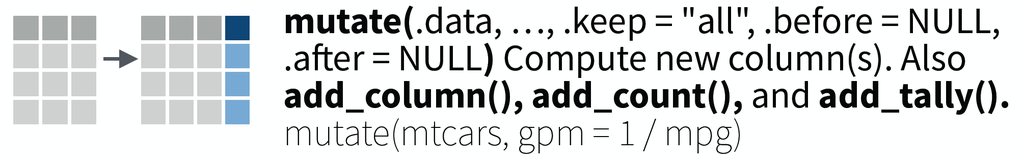

```r
#Modifica la columna de la masa y convierte los valores de kg a g
mutate(my_starwars, mass = mass*1000)
```

```
## # A tibble: 87 × 11
##    name    height   mass hair_color skin_color eye_color birth_year sex   gender
##    <chr>    <int>  <dbl> <chr>      <chr>      <chr>          <dbl> <chr> <chr>
##  1 Luke S…    172  77000 blond      fair       blue            19   male  mascu…
##  2 C-3PO      167  75000 <NA>       gold       yellow         112   none  mascu…
##  3 R2-D2       96  32000 <NA>       white, bl… red             33   none  mascu…
##  4 Darth …    202 136000 none       white      yellow          41.9 male  mascu…
##  5 Leia O…    150  49000 brown      light      brown           19   fema… femin…
##  6 Owen L…    178 120000 brown, gr… light      blue            52   male  mascu…
##  7 Beru W…    165  75000 brown      light      blue            47   fema… femin…
##  8 R5-D4       97  32000 <NA>       white, red red             NA   none  mascu…
##  9 Biggs …    183  84000 black      light      brown           24   male  mascu…
## 10 Obi-Wa…    182  77000 auburn, w… fair       blue-gray       57   male  mascu…
## # ℹ 77 more rows
## # ℹ 2 more variables: homeworld <chr>, species <chr>
```

## 3.4 Arrange

La función `arrange()` es equivalente a `sort()` de la unidad de **vectores**. Con `arrange()` podemos organizar datos de manera ascendente o descendente respecto a una columna del data frame o tibble. La sintaxis es la siguiente:

> `arrange(objeto, columna)`

Por ejemplo, nos interesa ordenar los datos de los personajes de la base con respecto a su año de nacimiento:

```r
arrange(my_starwars, birth_year)
```

```
## # A tibble: 87 × 11
##    name     height  mass hair_color skin_color eye_color birth_year sex   gender
##    <chr>     <int> <dbl> <chr>      <chr>      <chr>          <dbl> <chr> <chr>
##  1 Wicket …     88  20   brown      brown      brown            8   male  mascu…
##  2 IG-88       200 140   none       metal      red             15   none  mascu…
##  3 Luke Sk…    172  77   blond      fair       blue            19   male  mascu…
##  4 Leia Or…    150  49   brown      light      brown           19   fema… femin…
##  5 Wedge A…    170  77   brown      fair       hazel           21   male  mascu…
##  6 Plo Koon    188  80   none       orange     black           22   male  mascu…
##  7 Biggs D…    183  84   black      light      brown           24   male  mascu…
##  8 Han Solo    180  80   brown      fair       brown           29   male  mascu…
##  9 Lando C…    177  79   black      dark       brown           31   male  mascu…
## 10 Boba Fe…    183  78.2 black      fair       brown           31.5 male  mascu…
## # ℹ 77 more rows
## # ℹ 2 more variables: homeworld <chr>, species <chr>
```

O de forma inversa, deseamos ordenar los datos de los pacientes con respecto a la edad de forma descendente:

```r
arrange(my_starwars, desc(birth_year))
```

```
## # A tibble: 87 × 11
##    name     height  mass hair_color skin_color eye_color birth_year sex   gender
##    <chr>     <int> <dbl> <chr>      <chr>      <chr>          <dbl> <chr> <chr>
##  1 Yoda         66    17 white      green      brown            896 male  mascu…
##  2 Jabba D…    175  1358 <NA>       green-tan… orange           600 herm… mascu…
##  3 Chewbac…    228   112 brown      unknown    blue             200 male  mascu…
##  4 C-3PO       167    75 <NA>       gold       yellow           112 none  mascu…
##  5 Dooku       193    80 white      fair       brown            102 male  mascu…
##  6 Qui-Gon…    193    89 brown      fair       blue              92 male  mascu…
##  7 Ki-Adi-…    198    82 white      pale       yellow            92 male  mascu…
##  8 Finis V…    170    NA blond      fair       blue              91 male  mascu…
##  9 Palpati…    170    75 grey       pale       yellow            82 male  mascu…
## 10 Cliegg …    183    NA brown      fair       blue              82 male  mascu…
## # ℹ 77 more rows
## # ℹ 2 more variables: homeworld <chr>, species <chr>
```

> La opción `desc()` es equivalente a `decreasing =` de la función `sort()`

Como lo hemos visto dplyr es un paquete al cual se le puede extraer mucho jugo para realizar análisis de datos. Gracias a su sintaxis simple y al uso de pipes los análisis se vuelven altamente reproducibles y simples.

# 4 Tidyr

Tidyr es otro paquete de tidyverse que permite estructurar y organizar datos de una manera más simple. Como lo hemos visto, una tabla de datos organizada se analiza con una facilidad mayor. Además, su estructura organizada nos permite entender o comprender su contenido.

Tidyr nos ofrece una serie de funciones para estructurar nuestros datos en tibbles. Exploremos algunas de sus funciones:

Al crear bases de datos y tablas es comun encontrar datos faltantes en algunas columnas. Para ello, la celda **no debe dejarse vacía** y se debe de llenar con el valor **NA**. Existen diversas maneras de verificar la presencia de valores *NA* en las columnas de una tabla:

```r
##La función is.na() nos devuelve un vector lógico indicando TRUE si hay un valor NA o FALSE lo contrario
is.na(billboard)

##Al combinar la función table() nos devuelve la cantidad de valores TRUE (NA) o FALSE (no NA)
table(is.na(billboard$wk5))
```

[output not shown]

`drop_na()` es una función que elimina las filas que presentan un dato *NA* en alguna de las columnas que le especifiquemos. La sintaxis es la siguiente:

> `drop_na(objeto, columna)`

Eliminemos los datos *NA* presentes en la columna de wk5:

```r
##Elimina los valores NA de la columna Fibrato_2
drop_na(billboard, wk5)
```

```
## # A tibble: 292 × 79
##    artist     track date.entered   wk1   wk2   wk3   wk4   wk5   wk6   wk7   wk8
##    <chr>      <chr> <date>       <dbl> <dbl> <dbl> <dbl> <dbl> <dbl> <dbl> <dbl>
##  1 2 Pac      Baby… 2000-02-26      87    82    72    77    87    94    99    NA
##  2 3 Doors D… Kryp… 2000-04-08      81    70    68    67    66    57    54    53
##  3 3 Doors D… Loser 2000-10-21      76    76    72    69    67    65    55    59
##  4 504 Boyz   Wobb… 2000-04-15      57    34    25    17    17    31    36    49
##  5 98^0       Give… 2000-08-19      51    39    34    26    26    19     2     2
##  6 A*Teens    Danc… 2000-07-08      97    97    96    95   100    NA    NA    NA
##  7 Aaliyah    I Do… 2000-01-29      84    62    51    41    38    35    35    38
##  8 Aaliyah    Try … 2000-03-18      59    53    38    28    21    18    16    14
##  9 Adams, Yo… Open… 2000-08-26      76    76    74    69    68    67    61    58
## 10 Adkins, T… More  2000-04-29      84    84    75    73    73    69    68    65
## # ℹ 282 more rows
## # ℹ 68 more variables: wk9 <dbl>, wk10 <dbl>, wk11 <dbl>, wk12 <dbl>,
## #   wk13 <dbl>, wk14 <dbl>, wk15 <dbl>, wk16 <dbl>, wk17 <dbl>, wk18 <dbl>,
## #   wk19 <dbl>, wk20 <dbl>, wk21 <dbl>, wk22 <dbl>, wk23 <dbl>, wk24 <dbl>,
## #   wk25 <dbl>, wk26 <dbl>, wk27 <dbl>, wk28 <dbl>, wk29 <dbl>, wk30 <dbl>,
## #   wk31 <dbl>, wk32 <dbl>, wk33 <dbl>, wk34 <dbl>, wk35 <dbl>, wk36 <dbl>,
## #   wk37 <dbl>, wk38 <dbl>, wk39 <dbl>, wk40 <dbl>, wk41 <dbl>, wk42 <dbl>, …
```

`fill` es una función que nos permite llenar las celdas NA utilizando el primer valor que encuentre previamente a la celda NA

```r
fill(billboard, wk5)
```

```
## # A tibble: 317 × 79
##    artist     track date.entered   wk1   wk2   wk3   wk4   wk5   wk6   wk7   wk8
##    <chr>      <chr> <date>       <dbl> <dbl> <dbl> <dbl> <dbl> <dbl> <dbl> <dbl>
##  1 2 Pac      Baby… 2000-02-26      87    82    72    77    87    94    99    NA
##  2 2Ge+her    The … 2000-09-02      91    87    92    NA    87    NA    NA    NA
##  3 3 Doors D… Kryp… 2000-04-08      81    70    68    67    66    57    54    53
##  4 3 Doors D… Loser 2000-10-21      76    76    72    69    67    65    55    59
##  5 504 Boyz   Wobb… 2000-04-15      57    34    25    17    17    31    36    49
##  6 98^0       Give… 2000-08-19      51    39    34    26    26    19     2     2
##  7 A*Teens    Danc… 2000-07-08      97    97    96    95   100    NA    NA    NA
##  8 Aaliyah    I Do… 2000-01-29      84    62    51    41    38    35    35    38
##  9 Aaliyah    Try … 2000-03-18      59    53    38    28    21    18    16    14
## 10 Adams, Yo… Open… 2000-08-26      76    76    74    69    68    67    61    58
## # ℹ 307 more rows
## # ℹ 68 more variables: wk9 <dbl>, wk10 <dbl>, wk11 <dbl>, wk12 <dbl>,
## #   wk13 <dbl>, wk14 <dbl>, wk15 <dbl>, wk16 <dbl>, wk17 <dbl>, wk18 <dbl>,
## #   wk19 <dbl>, wk20 <dbl>, wk21 <dbl>, wk22 <dbl>, wk23 <dbl>, wk24 <dbl>,
## #   wk25 <dbl>, wk26 <dbl>, wk27 <dbl>, wk28 <dbl>, wk29 <dbl>, wk30 <dbl>,
## #   wk31 <dbl>, wk32 <dbl>, wk33 <dbl>, wk34 <dbl>, wk35 <dbl>, wk36 <dbl>,
## #   wk37 <dbl>, wk38 <dbl>, wk39 <dbl>, wk40 <dbl>, wk41 <dbl>, wk42 <dbl>, …
```

# 5 Referencias

Wickham, Hadley, Mara Averick, Jennifer Bryan, Winston Chang, Lucy McGowan, Romain François, Garrett Grolemund, et al. 2019. “Welcome to the Tidyverse.” *Journal of Open Source Software* 4 (43): 1686. https://doi.org/10.21105/joss.01686.